# ISyE 3770 HW8

Devin Fromond

2024-11-11

## Problem 8.1.1

### Part A

Given the margin of error is $2.14\frac{\sigma}{\sqrt{n}}$, we easily see $z=2.14$.

Using a Z-Table, we find the following:
$$P(Z\leq 2.14)\approx 0.9838$$
$$P(Z \leq -2.14)\approx 1-0.9838=0.0162$$
$$Confidence\ Level=0.9838-0.0162=0.9676\ or\ 96.76%$$

### Part B

We observe a Z-Score of $2.49$.

Using a Z-Table, we find the following:
$$P(Z\leq 2.49)\approx 0.9934$$
$$P(Z \leq -2.49)\approx 1-0.9934=0.0066$$
$$Confidence\ Level=0.9934-0.0066=0.9868\ or\ 98.68%$$

### Part C

We observe a Z-Score of $1.85$.

Using a Z-Table, we find the following:
$$P(Z\leq 1.85)\approx 0.9678$$
$$P(Z \leq -1.85)\approx 1-0.9678=0.0322$$
$$Confidence\ Level=0.9678-0.0322=0.9356\ or\ 93.56%$$

### Part D

We recognize this is a one-sided interval. We observe a Z-Score of $2.00$.

Using a Z-Table, we find the following:
$$P(Z\leq 2.00)\approx 0.9772$$
$$Confidence\ Level=P(\mu \leq
\bar{x}+2.00\frac{\sigma}{\sqrt{n}})=P(Z\leq2.00)=0.9772\ or\ 97.72%$$

### Part E

We recognize this is a one-sided interval. We observe a Z-Score of $1.96$.

Using a Z-Table, we find the following:
$$P(Z\leq 1.96)\approx 0.9750$$
$$Confidence\ Level=P(\mu \leq
\bar{x}-1.96\frac{\sigma}{\sqrt{n}})=P(Z\leq1.96)=0.9750\ or\ 97.50%$$

## Problem 8.1.5

### Part A

A higher confidence interval would take longer. Therefore, we find that a 99% CI would be longer than a 95% CI since the interval must be wider to account for greater variability in the sample data.

### Part B

The statement is not correct. For a CI $X%$, we find $X%$ of samples of those intervals would contain the true mean $\mu$. Furthermore, we find $\mu$ is not a random variable, so it is not within a specific interval. The provided statement treats $\mu$ as a random variable.

### Part C

We find the statement to be correct. The statement correctly interprets confidence intervals, as outlined in Part B. Out of 1000 confidence intervals, we would expect $\approx 950$ to include $\mu$, which we find to be consistent with the CI.

## Problem 8.1.7

### Part A

Therefore, we calculate standard error to be:
$$SE=\frac{\sigma}{\sqrt{n}}=\frac{0.001}{\sqrt{15}}=0.0002582mm$$

We compute the margin of error to be:
$$ME=Z_{0.005}(SE)=2.5758(0.0002582)=0.000664$$

### Part B

We find $Z_{0.99}\approx 2.3263$. Therefore, we calculate standard error to be:
$$SE=\frac{\sigma}{\sqrt{n}}=\frac{0.001}{\sqrt{15}}=0.0002582mm$$

We compute the margin of error to be:
$$ME=Z_{0.99}(SE)=2.3263(0.0002582)=0.000600$$

Therefore, we find the Lower Confidence Bound to be:
$$LCB=74.036-0.000600\approx 74.0354mm$$

We find the lower bound of the one-sided 99% confidence bound is slightly greater than that of the two-sided 99% confidence interval. We find this to be logical since the two-sided interval divides the significance level to each tail, thereby making it more conservative.

## Problem 8.2.10

### Part A

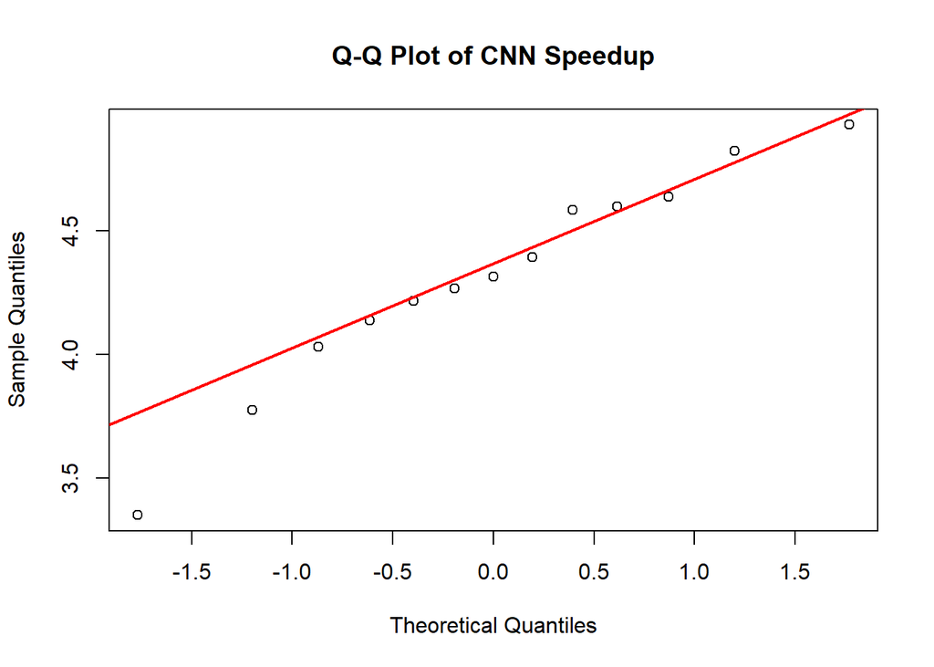

```r
speedup <- c(3.775302, 3.350679, 4.217981, 4.030324, 4.639692,
            4.139665, 4.395575, 4.824257, 4.268119, 4.584193,
            4.930027, 4.315973, 4.600101)

qqnorm(speedup, main="Q-Q Plot of CNN Speedup")
qqline(speedup, col="red", lwd=2)
```

Since the data points in the Q-Q plot lie approximately on the red line, we can conclude the speedup of CNN is normally distributed.

### Part B

We begin by calculating the sample mean:
$$\bar{x}=\frac{\sum x_i}{n}=\frac{56.071888}{13}=4.3132$$

We then calculate the sample standard deviation:
$$SST=\sum (x_i-\bar{x})^2=2.2478$$

Now, we find the variance to be:
$$S^2=\frac{SST}{n-1}=\frac{2.2478}{12}=0.1873$$

The standard deviation is trivial:
$$S=\sqrt{S^2}=0.4328$$

Therefore, we can calculate the standard error:
$$SE=\frac{S}{\sqrt{n}}=\frac{0.4328}{\sqrt{13}}=0.1201$$

We find the following:
$$t_{\alpha /2, n-1}=t_{0.025,12}=2.179$$

Therefore, we find the margin of error to be $2.179(0.1201)=0.2616$.

Then, the lower limit is calculated by $4.3132-0.2616=4.0515$ and the upper bound is $4.3132+0.2616=4.5748$.

### Part C

Using the values from part B, we simply find the following:
$$t_{\alpha , n-1}=t_{0.05,12}=1.782$$

Therefore, we find the margin of error to be $1.782(0.1201)=0.2140$.

Finally, the lower bound is found by $4.3132-0.2140=4.0992$.

## Problem 8.3.3

We begin by calculating the mean and standard deviation.

```r
temperatures <- c(20.1, 20.7, 20.9, 21.3, 21.6, 21.7, 21.7, 23.3)

mean_temp <- mean(temperatures)

sd_temp <- sd(temperatures)

print(mean_temp)
```

```
## [1] 21.4125
```

```r
print(sd_temp)
```

```
## [1] 0.9463275
```

For each temperature, we calculate the z-score.

```r
z_scores <- (temperatures - mean_temp) / sd_temp

temperature_data <- data.frame(
  Site = c("Harlquahala", "Laveen", "Maricopa", "Litchfield",
           "Phoenix Encanto", "Phoenix Greenway", "Waddell", "Sky Harbor Airport"),
  Temperature_C = temperatures,
  Z_Score = round(z_scores, 3)
)

print(temperature_data)
```

```
##                 Site Temperature_C Z_Score
## 1        Harlquahala          20.1  -1.387
## 2             Laveen          20.7  -0.753
## 3           Maricopa          20.9  -0.542
## 4         Litchfield          21.3  -0.119
## 5    Phoenix Encanto          21.6   0.198
## 6   Phoenix Greenway          21.7   0.304
## 7            Waddell          21.7   0.304
## 8 Sky Harbor Airport          23.3   1.995
```

Now, we plot the data!!!

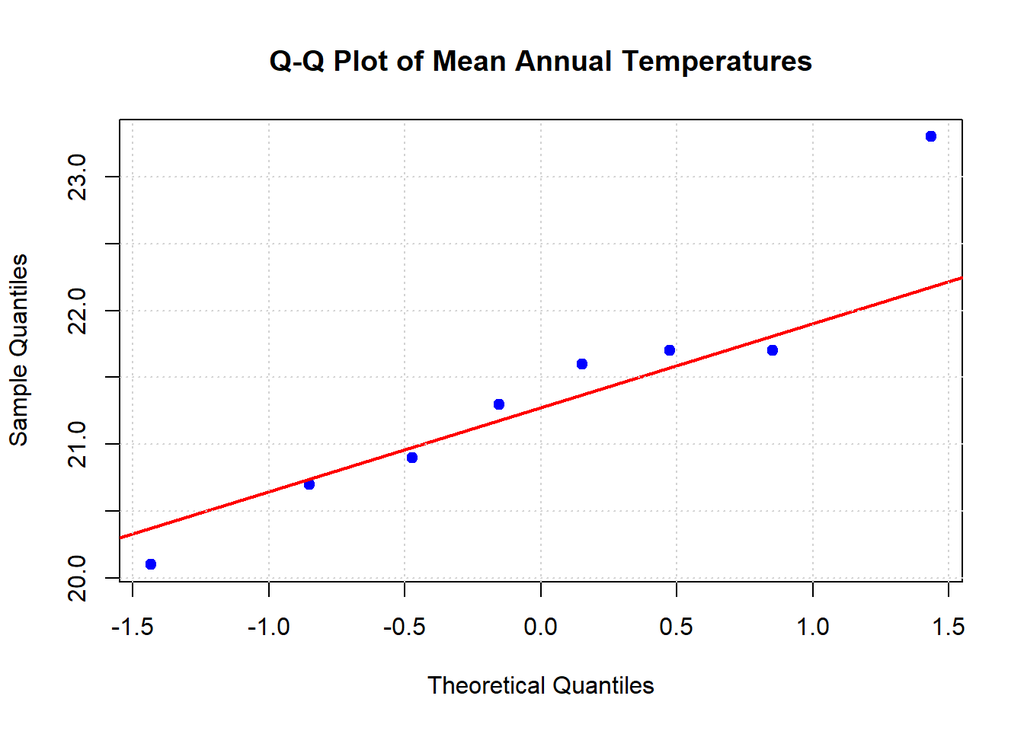

```r
qqnorm(temperatures, main = "Q-Q Plot of Mean Annual Temperatures", pch = 19, col = "blue")
qqline(temperatures, col = "red", lwd = 2)

grid()
```

Since most of the data points lie on or around the red line, we confirm the assumption of normality.

Now, we construct a 95% confidence interval.

Let’s use R to make this process easier…

```r
variance_temp <- var(temperatures)

df <- length(temperatures) - 1
alpha <- 0.05
chi_sq_lower <- qchisq(alpha / 2, df, lower.tail = FALSE)
chi_sq_upper <- qchisq(1 - alpha / 2, df, lower.tail = FALSE)

variance_lower <- (df * variance_temp) / chi_sq_lower
variance_upper <- (df * variance_temp) / chi_sq_upper

sd_lower <- sqrt(variance_lower)
sd_upper <- sqrt(variance_upper)
cat("95% Confidence Interval for Standard Deviation:\n")
```

```
## 95% Confidence Interval for Standard Deviation:
```

```r
cat("Lower Limit:", round(sd_lower, 3), "°C\n")
```

```
## Lower Limit: 0.626 °C
```

```r
cat("Upper Limit:", round(sd_upper, 3), "°C\n")
```

```
## Upper Limit: 1.926 °C
```

## Problem 8.4.1

### Part A

Ultimately, we wish to solve the following to determine the confidence intervals:
$$\hat{p} \pm Z_{\alpha/2}(\sqrt{\frac{\hat{p}(1-\hat{p})}{n}})$$
, where $\hat{p}=\frac{x}{n}$. We will use R to speed up calculations…

```r
x <- 412 # bush voters
n <- 768 # college grads
conf_level <- 0.95

p_hat <- x / n

z <- qnorm(1 - (1 - conf_level)/2)

SE <- sqrt(p_hat * (1 - p_hat) / n)

l_bound <- p_hat - z * SE
u_bound <- p_hat + z * SE

cat("We find the 95% Confidence Interval for p to be",
    round(l_bound, 5), "to", round(u_bound, 5))
```

```
## We find the 95% Confidence Interval for p to be 0.50119 to 0.57173
```

### Part B

We find $\hat{p}=\frac{412}{768}=0.5365$.

Using R,

```r
z_lower <- qnorm(conf_level)

lower_conf_bound <- p_hat - z_lower * SE

cat("95% Lower Confidence Bound for p:", round(lower_conf_bound, 5))
```

```
## 95% Lower Confidence Bound for p: 0.50686
```

And so, we have arrived at our answer of 50.69% for the 95% LCB.